# R Notebook

# Aufgabenstellung: Einfache Regressionsanalyse

Viele Menschen behaupten, dass bei ihnen erst der erste Schneefall Weihnachtsgefühle weckt. Eine Forschungsgruppe möchte untersuchen, ob Schneefall tatsächlich die Weihnachtsstimmung steigert. Eine bereits veröffentlichte Studie konnte zeigen, dass die Weihnachtsstimmung durch die Anzahl gekaufter Weihnachtsdekorationsartikel operationalisiert werden kann. Die Forschungsgruppe formuliert nun die folgende Forschungsfrage: Besteht ein Zusammenhang zwischen der Anzahl schneefallreicher Tage in der Vorweihnachtszeit und dem Umsatz (in Tausend Schweizer Franken) in Dekorationsgeschäften (n = 212)? Der zu analysierende Datensatz enthält daher neben einer Identifikationsnummer des Dekorationsgeschäfts (id) eine Variable, die den Umsatz erfasst (deko), und eine, die die Anzahl Tage mit Schneefall wiedergibt (schnee).

Variable1 (AV): deko Varibale2 (UV): schnee

## 1) Hypothese:

ungerichtete Zusammenhangshypothese:

H1: Es gibt einen Zusammenhang zwischen der Anzahl schneefallreicher Tage in der Vorweihnachtszeit und dem Umsatz (in Tausend Schweizer Franken) in Dekorationsgeschäften.

H0: Es gibt keinen Zusammenhang zwischen der Anzahl schneefallreicher Tage in der Vorweihnachtszeit und dem Umsatz (in Tausend Schweizer Franken) in Dekorationsgeschäften.

## 2) Voraussetzungen der einfachen Regressionsanalyse:

Die abhängige und die unabhängige Variable sind intervallskaliert. UV schnee ist metrisch und die AV deko ist ebenfalls metrisch.

Linearität des Zusammenhangs: Es wird ein linearer Zusammenhang zwischen der abhängigen und der unabhängigen Variablen modelliert. <-siehe Scatterplot und Pearson

Unabhängigkeit des Fehlerwerts: Die Fehlerwerte hängen nicht voneinander ab. <- siehe Homoskedastizität

Normalverteilung des Fehlerwerts: Die Fehlerwerte sind näherungsweise normalverteilt. <- siehe Histogramm

## 3) Grundlegende Konzepte: Was ist einfache Regression?:

Die einfache Regressionsanalyse oder bivariate Regression wird angewendet, wenn geprüft werden soll, ob ein Zusammenhang zwischen zwei intervallskalierten Variablen besteht. Ziel ist das Zurückgehen von der abhängigen Variable y auf die unabhängige Variable x.Die abhängige Variable wird auch als “Kritieriumsvariable” und die unabhängige Variable als “Prädiktorvariable” bezeichnet.

Es könne drei Arten von Fragestellungen untersucht werden:

Ursachenanalyse: Gibt es einen Zusammenhang zwischen der unabhängigen und der abhängigen Variable? Wie eng ist dieser? Wirkungsanalyse: Wie verändert sich die abhängige Variable bei einer Änderung der unabhängigen Variablen? Prognose: Können die Messwerte der abhängigen Variable durch die Werte der unabhängigen Variable vorhergesagt werden?

Kurz um: “Wie beeinflusst eine unabhängige Variablen die abhängige Variable?”

## 4) Prüfen der Voraussetzungen:

```r
library(readr)
regression <- read_csv("uebung8.csv")
regression
```

| id | deko | schnee |
| --- | --- | --- |
| 1 | 3.25 | 15 |
| 2 | 4.38 | 16 |
| 3 | 12.39 | 14 |
| 4 | 7.78 | 14 |
| 5 | 19.98 | 14 |
| 6 | 5.71 | 16 |
| 7 | 13.08 | 17 |
| 8 | 11.90 | 13 |
| 9 | 7.14 | 18 |
| 10 | 4.65 | 16 |

[output cut: 202 more lines]

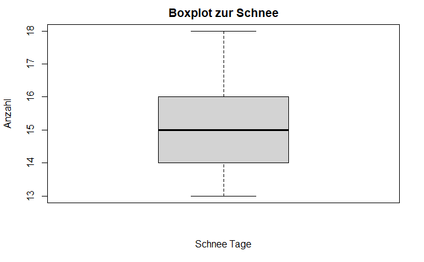

```r
boxplot(regression$schnee, main="Boxplot zur Schnee", xlab="Schnee Tage", ylab="Anzahl")
```

Es liegen keine Ausreißer in der Einzelbetrachtung vor.

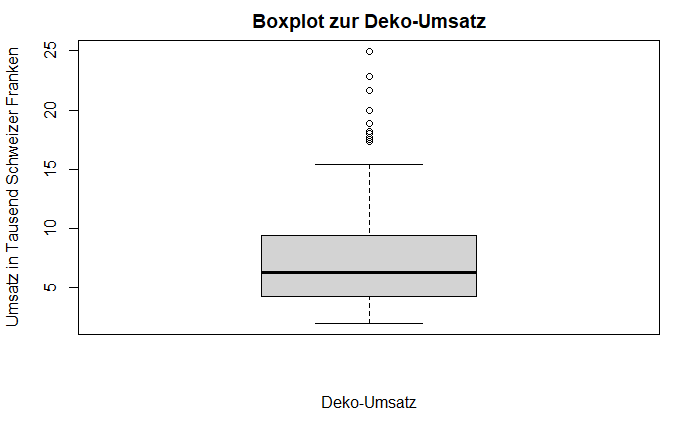

```r
umsatz <- boxplot(regression$deko, main="Boxplot zur Deko-Umsatz", xlab="Deko-Umsatz", ylab="Umsatz in Tausend Schweizer Franken")
```

Es gibt einige Ausreißer. Grundsätzlich ist das für diese Auswertung eher kein Problem, da der Datensatz relativ groß ist.

```r
View(regression)
```

### Ausreißer finden und löschen:

```r
ausreisser <- umsatz$out
ausreisser
```

```
 [1] 19.98 24.98 22.86 18.89 18.16 21.63 18.16 18.00 18.18 17.33 17.50 17.71
```

### Descriptive Statistik:

Für die deskriptive Statistik empfiehlt es sich das Package “psych” zu verwenden.

```r
library(psych)
describe(regression)
```

|  | vars | n | mean | sd | median | trimmed | mad | min | max | range | skew | kurtosis | se |
| --- | --- | --- | --- | --- | --- | --- | --- | --- | --- | --- | --- | --- | --- |
| id | 1 | 212 | 106.50 | 61.34 | 106.50 | 106.50 | 78.58 | 1 | 212.00 | 211.00 | 0.00 | -1.22 | 4.21 |
| deko | 2 | 212 | 7.39 | 4.30 | 6.25 | 6.73 | 3.48 | 2 | 24.98 | 22.98 | 1.45 | 2.09 | 0.30 |
| schnee | 3 | 212 | 15.08 | 1.53 | 15.00 | 14.99 | 1.48 | 13 | 18.00 | 5.00 | 0.24 | -0.95 | 0.11 |

Die Schneetage liegt bei 15.08 (SD=1.53, n= 212). Die Deko-Umsatz legt bei 7.39 Tausend Schweizer Franken (SD= 4.30, n= 212). Es zeigt sich, dass Die Deko-Umsatz nach oben verschoben ist (Median=6.25 Tausend Schweizer Franken).

### Scatterplot und Pearson:

Es gilt anzumerken, dass auch nicht-lineare Zusammenhänge zwischen y und x mittels Regressionsanalyse untersucht werden können. Dazu wird der Zusammenhang vor der Regressionsanalyse derart transformiert, dass er linear wird. Dies geschieht durch eine Transformation von y und/oder x. Anschliessend wird nicht der Zusammenhang zwischen y und x modelliert, sondern zwischen den allenfalls transformierten Variablen.

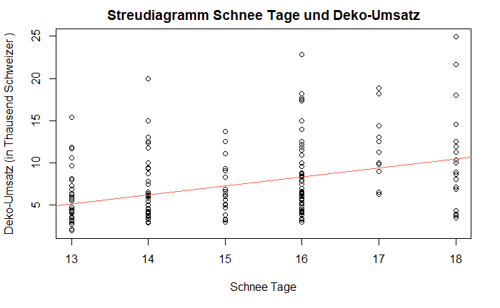

```r
plot( regression$deko ~ regression$schnee, main= "Streudiagramm Schnee Tage und Deko-Umsatz", xlab = "Schnee Tage" , ylab="Deko-Umsatz (in Thausend Schweizer )")
abline(lm(deko ~ schnee, data = regression), col="tomato")
```

Das Streudiagramm lässt für das Beispiel einen positiven Zusammenhang vermuten. Damit scheint die Voraussetzung, dass der Zusammenhang an sich linear ist, erfüllt.

```r
test <- cor.test(regression$schnee, regression$deko)
test
```

```
    Pearson's product-moment correlation

data:  regression$schnee and regression$deko
t = 5.9541, df = 210, p-value = 1.086e-08
alternative hypothesis: true correlation is not equal to 0
95 percent confidence interval:
 0.2585334 0.4897134
sample estimates:
      cor
0.3800428
```

Der R-Output in Abbildung gibt den Korrelationskoeffizienten sowie den p-Wert (Signifikanz) und die Stichprobengrösse n wieder. Es wird ersichtlich, dass ein Zusammenhang vorliegt zwischen Schneetage und Dekoumsaetzen (r = 0.3800428 , p= .000, n = 212). Da r einen positiven Wert aufweist, kann von einem positiven, linearen und signifikanten Zusammenhang zwischen Schneetage und Dekoumsaetzen ausgegangen werden.

Da der Korrelation mittelstark und signifikant ist, ist es sinnvoll eine Regression durchzuführen zur Prüfung der Kausalität.

### Homoskedastizität:

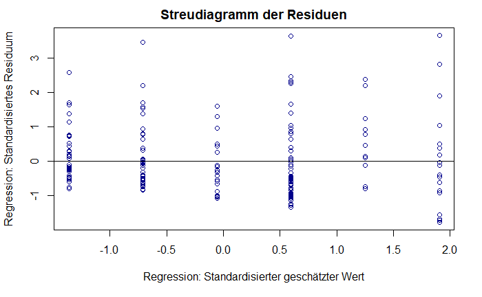

```r
regression1 <-  lm(regression$deko ~ regression$schnee)

zpred <- scale(fitted(regression1), center = T, scale = T)
sres <-rstandard(regression1)

plot (x=zpred, y=sres, main = "Streudiagramm der Residuen",
      xlab ="Regression: Standardisierter geschätzter Wert",
      ylab = "Regression: Standardisiertes Residuum",
      col = "darkblue")

abline (a=0, b=0)
```

Bei der optischen Prüfung der Daten prüfen wir auf Homoskedastizität. Unsere Daten lassen auf Homoskedastizität schließen. Das wäre nicht der Fall, wenn die Daten eher Trompetenform sich darstellen. Gerne kann hier großzügig gearbeitet werden.

### Histogramme:

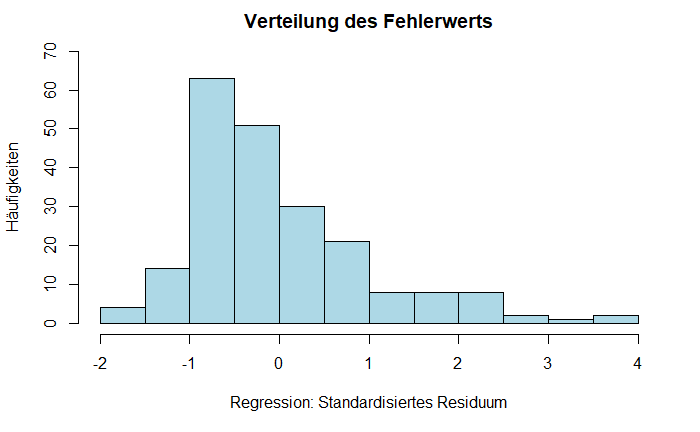

```r
hist (sres, freq = T, breaks = 10, main ="Verteilung des Fehlerwerts", xlab= "Regression: Standardisiertes Residuum", ylab="Häufigkeiten", xlim = c(-2,4),ylim = c(0,70), col = "lightblue" )
```

Zur Überprüfung, ob das Regressionsmodell insgesamt signifikant ist, wird ein F-Test durchgeführt. Dieser prüft, ob die Vorhersage der abhängigen Variablen durch das Hinzufügen der unabhängigen Variablen verbessert wird. Das heisst, der F-Test prüft, ob das Modell insgesamt einen Erklärungsbeitrag leistet.

```r
regression1 <-  lm(regression$deko ~ regression$schnee)

reg <- summary(regression1)
reg
```

```
Call:
lm(formula = regression$deko ~ regression$schnee)

Residuals:
   Min     1Q Median     3Q    Max
-7.004 -2.600 -1.235  1.651 14.491

Coefficients:
                  Estimate Std. Error t value Pr(>|t|)
(Intercept)        -8.7060     2.7176  -3.204  0.00157 **
regression$schnee   1.0672     0.1792   5.954 1.09e-08 ***
---
Signif. codes:  0 ‘***’ 0.001 ‘**’ 0.01 ‘*’ 0.05 ‘.’ 0.1 ‘ ’ 1

Residual standard error: 3.986 on 210 degrees of freedom
Multiple R-squared:  0.1444,    Adjusted R-squared:  0.1404
F-statistic: 35.45 on 1 and 210 DF,  p-value: 1.086e-08
```

Hinweis -> Zuerst die abhängige Varibale nennen und dann die unabhängige Varibale. In unserem Beispiel ist die AV = deko und die UV = schnee